# Mapa de Regresão Linear

Jedielso Sales de Souza

2024-02-22

# Introdução

A variável resposta em destaque será a temperatura máxima, cujas variações serão exploradas e relacionadas com as variáveis preditoras de altitude, latitude e longitude. Essas variáveis geográficas desempenham um papel crucial na compreensão dos padrões climáticos, e a regressão linear nos permitirá investigar como esses fatores influenciam as temperaturas máximas.

Além disso, a estimação para todo o estado será aprimorada por meio da utilização dos dados de relevo do estado do Rio de Janeiro, os quais serão obtidos na Embrapa. Essa abordagem mais abrangente nos permitirá não apenas compreender as relações climáticas locais, mas também considerar as características topográficas do ambiente, enriquecendo assim a nossa análise.

## Pacotes Utilizados

```r
## Manipulação de dados
library(dplyr)
library(janitor)
library(readr)

# Tabelas
library(DT)
library(knitr)

# Manipulação de dados espaciais
library(geobr) # Acessar dados do IBGE
library(raster) # Tipo raster
library(sf) # Tipo vetorial
```

```r
## Plot e Mapa
library(ggplot2) # Plot
library(ggspatial) # Escala e orientação
library(fields) # Paleta de cores
```

# Dados Espaciais

Inicialmente, procederemos à manipulação dos dados raster que representam o relevo do estado do Rio de Janeiro.

Os dados topográficos necessários estão disponíveis para download no site da [Embrapa](https://www.embrapa.br/satelites-de-monitoramento/missoes/srtm), na seção “Brasil Relevo”, acessand o menu “Projeto, Dados para download” e selecionando o estado do Rio de Janeiro.

Os dados do relevo do estado estão organizados em várias cenas, apresentadas como arquivos do tipo TIFF (Figura 1).

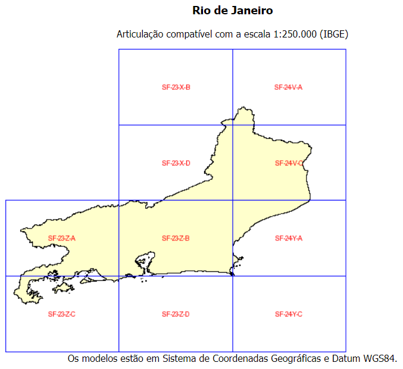

*Figura 1: Cenas do relevo do estado do Rio de Janeiro. Fonte: Embrapa*

Cada cena é baixada em uma pasta diferente.

## Carregando os dados tipo raster

```r
## Listando o nome das pastas de relevo
list.files("dados/relevo/")
```

```
##  [1] "sf-23-x-b" "sf-23-x-d" "sf-23-z-a" "sf-23-z-b" "sf-23-z-c" "sf-23-z-d"
##  [7] "sf-24-v-a" "sf-24-v-c" "sf-24-y-a" "sf-24-y-c"
```

```r
## Verificando os arquivos dentro de cada pasta
list.files("dados/relevo/sf-23-x-b/")
```

```
## [1] "sf-23-x-b.aux" "sf-23-x-b.rrd" "SF-23-X-B.tif"
```

Nossa atenção está concentrada nos arquivos do tipo TIFF, os quais são particularmente relevantes para a próxima etapa da análise.

```r
## Listando os arquivos .tif dentro da pasta relevo
arquivos <- list.files(pattern = "*.tif", path = "dados/relevo/",
                       recursive = T, # Busca em todas as pastas da pasta relevo
                       full.names = T) # Retorna o nome completo do arquivo

arquivos # Listando os arquivos .tif
```

```
##  [1] "dados/relevo/sf-23-x-b/SF-23-X-B.tif"
##  [2] "dados/relevo/sf-23-x-d/SF-23-X-D.tif"
##  [3] "dados/relevo/sf-23-z-a/SF-23-Z-A.tif"
##  [4] "dados/relevo/sf-23-z-b/SF-23-Z-B.tif"
##  [5] "dados/relevo/sf-23-z-c/SF-23-Z-C.tif"
##  [6] "dados/relevo/sf-23-z-d/SF-23-Z-D.tif"
##  [7] "dados/relevo/sf-24-v-a/SF-24-V-A.tif"
##  [8] "dados/relevo/sf-24-v-c/SF-24-V-C.tif"
##  [9] "dados/relevo/sf-24-y-a/SF-24-Y-A.tif"
## [10] "dados/relevo/sf-24-y-c/SF-24-Y-C.tif"
```

```r
## Carregando todas as cenas
cenas <- lapply(arquivos, raster::raster)

cenas[1] # Exibindo os dados da cena 1
```

```
## [[1]]
## class      : RasterLayer
## dimensions : 1200, 1800, 2160000  (nrow, ncol, ncell)
## resolution : 0.0008333334, 0.0008333334  (x, y)
## extent     : -43.50042, -42.00042, -21.00042, -20.00042  (xmin, xmax, ymin, ymax)
## crs        : +proj=longlat +datum=WGS84 +no_defs
## source     : SF-23-X-B.tif
## names      : SF.23.X.B
## values     : 184, 2076  (min, max)
## attributes :
##         ID Histogram
##  from:   0       481
##   to : 255         4
```

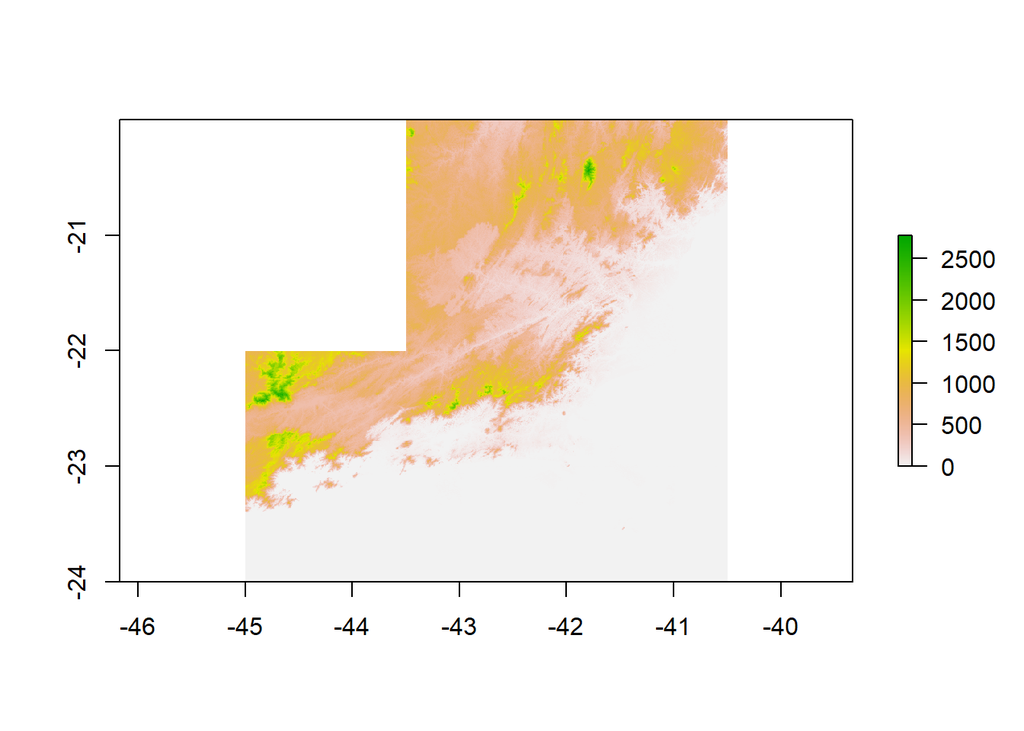

```r
## Juntando as cenas
cenas_juntas <- do.call(merge, cenas)

raster::plot(cenas_juntas) # Plotando as cenas
```

Observe que as cenas abrangem uma área mais ampla do que o próprio estado do Rio de Janeiro. No próximo passo, realizaremos a manipulação dos dados, implementando procedimentos de recorte e mascaramento para focalizar especificamente no estado do Rio.

## Manipulação dos dados tipo raster

```r
## Carregando os dados vetoriais dos limites do estado do Rio de Janeiro
# Por padrão são retornados os dados de 2010
limite <- geobr::read_state(code_state = "RJ", showProgress = F)
```

```
## Using year 2010
```

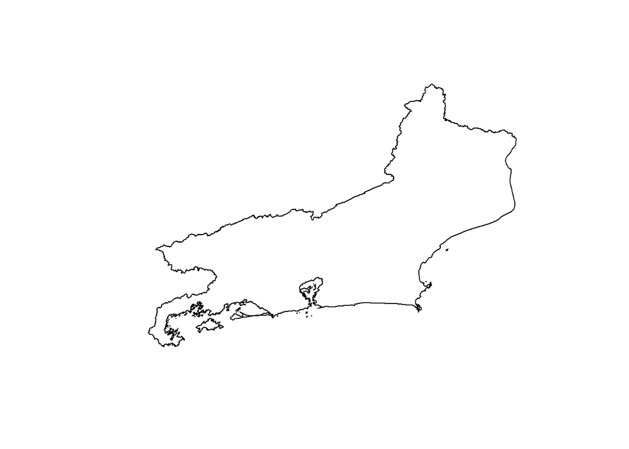

```r
# Plotando os dados
plot(limite$geom)
```

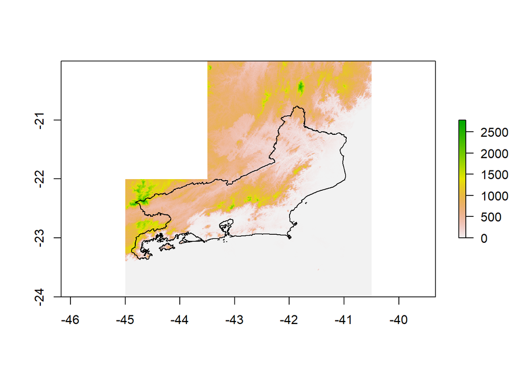

```r
## Sobrepondo dos mapas
raster::plot(cenas_juntas)
plot(limite$geom, add = T)
```

### Verificando o sistema de coordenadas

```r
## Sistema de coordenadas do relevo (raster)
raster::crs(cenas_juntas)
```

```
## Coordinate Reference System:
## Deprecated Proj.4 representation: +proj=longlat +datum=WGS84 +no_defs
## WKT2 2019 representation:
## GEOGCRS["unknown",
##     DATUM["World Geodetic System 1984",
##         ELLIPSOID["WGS 84",6378137,298.257223563,
##             LENGTHUNIT["metre",1]],
##         ID["EPSG",6326]],
##     PRIMEM["Greenwich",0,
##         ANGLEUNIT["degree",0.0174532925199433],
##         ID["EPSG",8901]],
##     CS[ellipsoidal,2],
##         AXIS["longitude",east,
##             ORDER[1],
##             ANGLEUNIT["degree",0.0174532925199433,
##                 ID["EPSG",9122]]],
##         AXIS["latitude",north,
##             ORDER[2],
##             ANGLEUNIT["degree",0.0174532925199433,
##                 ID["EPSG",9122]]]]
```

```r
## Sistema de coordenadas dos limites (vetorial)
sf::st_crs(limite)$proj4string
```

```
## [1] "+proj=longlat +ellps=GRS80 +towgs84=0,0,0,0,0,0,0 +no_defs"
```

Observe que os arquivos raster e vetorial estão utilizando sistemas de coordenadas distintos. O arquivo raster está configurado em +proj=longlat +datum=WGS84 +no_defs, enquanto o arquivo vetorial utiliza +proj=longlat +ellps=GRS80 +towgs84=0,0,0,0,0,0,0 +no_defs.

É crucial garantir a uniformidade desses sistemas para manter a integridade e confiabilidade das análises geoespaciais. Recomenda-se fortemente ter todos os conjuntos de dados em um único sistema de coordenadas. Essa abordagem facilita a realização de análises precisas e a interpretação correta dos resultados.

```r
## Atribuindo o sistema de coordenadas do raster no vetorial
limite <- limite |>
  sf::st_transform("+proj=longlat +datum=WGS84 +no_defs")
```

```r
## Verificando o sistema de coordenadas após a transformação
sf::st_crs(limite)$proj4string
```

```
## [1] "+proj=longlat +datum=WGS84 +no_defs"
```

### Recorte

```r
## Recortando as cenas de relevo de acordo com os limites do estado do Rio
recorte <- raster::crop(cenas_juntas, limite)
```

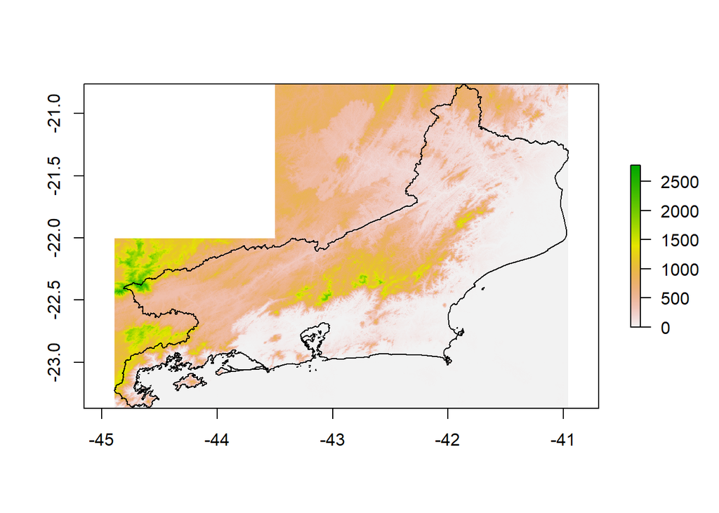

```r
## Visualizando os arquivos após o recorte
raster::plot(recorte)
plot(limite$geom, add = T)
```

### Máscara

```r
## Mascarando o recorte fora dos limites do estado do Rio
relevo_rj <- raster::mask(recorte, limite)
```

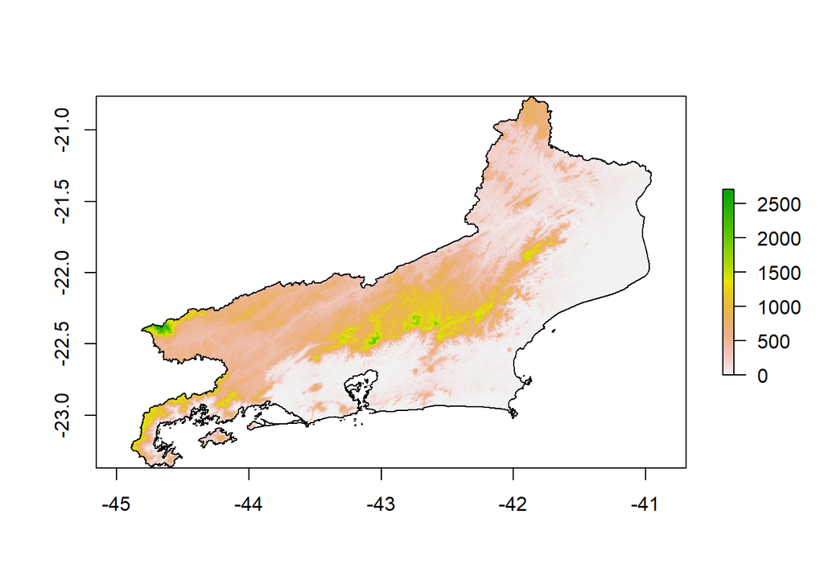

```r
## Visualizando os arquivos após a máscara
raster::plot(relevo_rj)
plot(limite$geom, add = T)
```

# Dados do INMET

Os dados de temperatura podem ser obtidos no site do [INMET](https://portal.inmet.gov.br/), na seção ‘Dados Meteorológicos’, mais especificamente em ‘Banco de Dados Meteorológicos’.

Os registros são organizados anualmente e disponibilizados em arquivos .csv para cada estação meteorológica. Cada arquivo inicia com um cabeçalho de metadados nas oito primeiras linhas, contendo informações como latitude, longitude e altitude. A nona linha e as subsequentes contêm as variáveis e medições realizadas pela estação, apresentadas em intervalos horários (Figura 2).

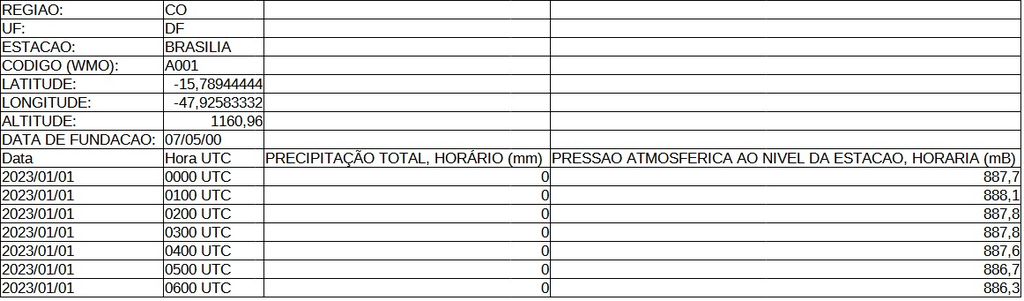

*Figura 2: Print do arquivo csv com os dados de uma das estações. Fonte: INMET*

Para manipular eficientemente esses dados, será necessário desenvolver uma função personalizada. A tarefa dessa função será carregar todos os arquivos, separar os metadados das oito primeiras linhas dos dados a partir da nona linha e, por fim, realizar cálculos agregados por mês, consolidando essas informações em um único dataframe. Este dataframe resultante conterá os dados de temperatura, precipitação, altitude, latitude, longitude, entre outros.

```r
# Quantidade de arquivos (estações) da pasta de 2023
length(list.files("dados/INMET_2023/"))
```

```
## [1] 567
```

```r
# Exibindo nome do primeiro arquivo
list.files("dados/INMET_2023/")[1]
```

```
## [1] "INMET_CO_DF_A001_BRASILIA_01-01-2023_A_31-12-2023.CSV"
```

## Função INMET

```r
## Função para manipulação dos dados das estações do INMET
funcao_INMET <- function(){

  # Listantando o nome completo de todos arquivos do tipo csv da pasta
  arquivos_csv <- list.files(pattern = "*.CSV", path = "dados/INMET_2023/",
                              full.names = T)
  ##############################################################################
  ####### Função para carregar as variáveis medidas nas estações ###############
  ##############################################################################
  funcao_medicoes <- function(X){
    readr::read_csv2(X, skip = 8, # Pulando as 8 primeiras linhas
                     # Ajust. o enconding e definindo a , como separador de dec.
                     locale = readr::locale(encoding = "latin1",
                                            dec = ",")) |> #
      # Limpando os nomes de variáveis
      janitor::clean_names() |>
      # Retirando o mês da variável data e atribuindo a uma variável mês
      dplyr::mutate(mes = format(as.POSIXct(data), "%m")) |>
      # Agrupando por mês
      dplyr::group_by(mes) |>
      # Calculando as medidas de interesse
      dplyr::summarise(
        prec_total = as.numeric(sum(na.omit(precipitacao_total_horario_mm))),
        pressao_atm = as.numeric(mean(na.omit(pressao_atmosferica_ao_nivel_da_estacao_horaria_m_b))),
        pressao_atm_max = as.numeric(max(na.omit(pressao_atmosferica_max_na_hora_ant_aut_m_b))),
        pressao_atm_min = as.numeric(min(na.omit(pressao_atmosferica_min_na_hora_ant_aut_m_b))),
        radiacao = as.numeric(mean(na.omit(radiacao_global_kj_m2))),
        temp_ar_media = as.numeric(mean(na.omit(temperatura_do_ar_bulbo_seco_horaria_c))),
        temp_orvalho_media = as.numeric(mean(na.omit(temperatura_do_ponto_de_orvalho_c ))),
        temp_max = as.numeric(max(na.omit(temperatura_maxima_na_hora_ant_aut_c))),
        temp_min = as.numeric(min(na.omit(temperatura_minima_na_hora_ant_aut_c))),
        temp_orvalho_max = as.numeric(max(na.omit(temperatura_orvalho_max_na_hora_ant_aut_c))),
        temp_orvalho_min = as.numeric(min(na.omit(temperatura_orvalho_min_na_hora_ant_aut_c))),
        umidade_rel_max_perc = as.numeric(max(na.omit(umidade_rel_max_na_hora_ant_aut_percent))),
        umidade_rel_min_perc = as.numeric(min(na.omit(umidade_rel_min_na_hora_ant_aut_percent))),
        umidade_rel_media_perc = as.numeric(mean(na.omit(umidade_relativa_do_ar_horaria_percent))),
        vel_vento_max = as.numeric(max(na.omit(vento_rajada_maxima_m_s))),
        vel_vento_media = as.numeric(mean(na.omit(vento_velocidade_horaria_m_s)))) |>
      # Selecionando as variáveis de interesse
      dplyr::select(mes, prec_total, pressao_atm, pressao_atm_max, pressao_atm_min,
                    radiacao, temp_ar_media, temp_orvalho_media, temp_max, temp_min,
                    temp_orvalho_max, temp_orvalho_min, umidade_rel_max_perc,
                    umidade_rel_min_perc, umidade_rel_media_perc,
                    vel_vento_max, vel_vento_media)

  }


  ##############################################################################
  ####### Função para carregar os metadados de geolocalização das estações #####
  ##############################################################################
  funcao_estacoes <- function(X){

    ####### Passo 1 ############################################################
    ####### Carregando os metadados dados de geolocalização das estações #######

    # Carregando os dados e retirando 8 primeiras linhas
    # A primeira linha se torna o nome das variáveis
    estacoes1 <- readr::read_csv2(X, n_max = 7,
                     # Definindo a virgula como decimal
                     locale = readr::locale(encoding = "latin1", dec = ","))

    ###### Passo 2 #############################################################
    ###### Arrumando os dados ##################################################
    estacoes2 <- estacoes1 |>
      ## A var2 possui diferentes nomes - SE (sudentes), CO (centro-oeste), etc
      ## Todas var2 receberam o nome de XX para possibilitar a rotação do df
      # Transformando o nome da var 2 em XX
      dplyr::rename(XX = names(estacoes1[2])) |>
      # Rotacionando o df
      tidyr::pivot_wider(names_from = `REGIAO:`, values_from = XX) |>
      # Limpando os nomes das variáveis
      janitor::clean_names() |>
      # Definindo as variáveis de geolocalização e substituindo , por . para
      # tornar a variável numérica
      dplyr::mutate(latitude = as.numeric(sub(",",".", latitude)),
                    longitude = as.numeric(sub(",",".", longitude)),
                    altitude = as.numeric(sub(",",".", altitude))) |>
      # Selecionando todas colunas, menos data_fundacao
      dplyr::select(-(data_de_fundacao)) |>
      # Repetindo a linha 12 vezes
      dplyr::slice(rep(1, 12))

    return(estacoes2)
  }

  # Carregando todos os arquivos de medições das diversas estações separadamente
  dados_medicoes_separados <- lapply(arquivos_csv, funcao_medicoes)

  # Juntando os arquivos das diversas estações em um
  dados_medicoes_juntos <- do.call(dplyr::bind_rows, dados_medicoes_separados)

  # Carregando todos os arquivos
  dados_estacoes_separados <- lapply(arquivos_csv, funcao_estacoes)

  # Juntando os arquivos por linhas
  dados_estacoes_juntos <- do.call(dplyr::bind_rows, dados_estacoes_separados)

  ## Juntando os dados de medições com os dados das estações
  dados_completos <- dplyr::bind_cols(dados_estacoes_juntos, dados_medicoes_juntos)

  return(dados_completos)
}
```

```r
# Executando a função para manipulação dos dados do INMET e carregando na pasta dados
dados <- funcao_INMET()
```

```r
# Salvando o dataframe em arquivo csv para não precisar executar a função novamente
write.csv2(dados, file = "dados/INMET_2023_arrumados/dados_arrumados.csv")
```

```r
# Carregando os dados a partir do arquivo csv salvo
dados_arrumados <- read.csv2("dados/INMET_2023_arrumados/dados_arrumados.csv")
```

## Visualização dos dados das estações

```r
# Filtrando os dados para o estado do Rio de Janeiro
dados_rj <- dados_arrumados |>
  dplyr::filter(uf == "RJ") |>
  dplyr::mutate(mes_abreviado = case_when(
    mes == 1 ~ "jan",
    mes == 2 ~ "fev",
    mes == 3 ~ "mar",
    mes == 4 ~ "abr",
    mes == 5 ~ "mai",
    mes == 6 ~ "jun",
    mes == 7 ~ "jul",
    mes == 8 ~ "ago",
    mes == 9 ~ "set",
    mes == 10 ~ "out",
    mes == 11 ~ "nov",
    mes == 12 ~ "dez"))

# Ordenando os meses e classificando como factor
ordem_meses <- c("jan", "fev", "mar", "abr", "mai", "jun", "jul", "ago", "set", "out", "nov", "dez")
dados_rj$mes_abreviado <- factor(dados_rj$mes_abreviado, levels = ordem_meses)
```

### Disposição geográfica das estações

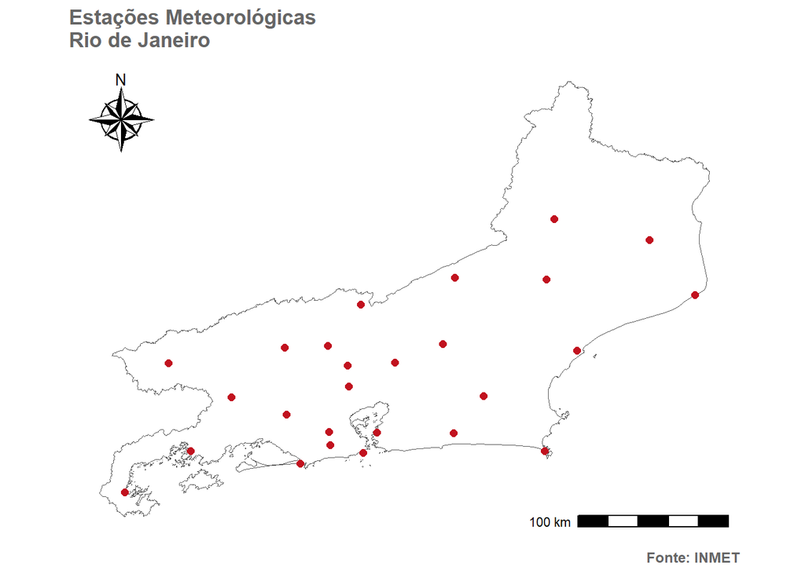

```r
mapa_estacoes <- ggplot() +
  geom_sf(data = limite, fill = "transparent") +
  geom_point(dados_rj,
             mapping = aes(x = longitude,
                           y = latitude),
             shape = 21, size = 2, fill = "#C1121F", color = "#C1121F") +
  annotation_scale(location = "br") +
  annotation_north_arrow(location = "tl",
                         style = north_arrow_nautical(),
                         height = unit(1.8, "cm"),
                         width = unit(1.8, "cm")) +
  labs(x = NULL, y = NULL, fill = NULL, col = NULL,
       title = "Estações Meteorológicas\nRio de Janeiro",
       caption = "Fonte: INMET") +
  theme_minimal() +
  theme(text = element_text(color = "grey40"),
        plot.title = element_text(size = 13, face = "bold"),
        plot.caption = element_text(size = 9, color = "gray40", face = "bold"),
        axis.ticks = element_blank(),
        axis.text = element_blank(),
        panel.grid = element_blank())

mapa_estacoes
```

### Boxplot das Temperaturas Máximas

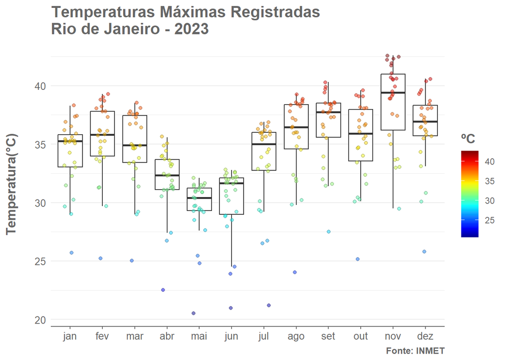

```r
boxplot_temp_max <- ggplot(dados_rj, aes(x = mes_abreviado, y = temp_max)) +
  geom_boxplot(outlier.shape = NA) +
  geom_jitter(aes(fill = temp_max),
              position = position_jitter(width = 0.2),
              shape = 21,
              col = "grey30",
              alpha = 0.5) +
    labs(y = "Temperatura(°C)\n", x = NULL, fill = "ºC",
         title = "Temperaturas Máximas Registradas\nRio de Janeiro - 2023",
         caption = "Fonte: INMET") +
    scale_fill_gradientn(colours = tim.colors(20)) +
    theme_minimal() +
    theme(panel.grid.major.x = element_blank(),
          text = element_text(color = "grey40"),
          axis.line.x = element_line(color = "gray40"),
          axis.ticks.x = element_line(color = "gray40"),
          axis.text = element_text(colour = "gray40", size = 10),
          plot.caption = element_text(size = 9, color = "gray40"),
          title = element_text(size = 13, face = "bold"))

boxplot_temp_max
```

# Modelo de Regresão Linear

```r
## Criando um dataframe para o mês de maio
temp_max_5 <- dados_rj |>
  dplyr::filter(mes == 5) |>
  dplyr::mutate(alt = altitude, lon = longitude, lat = latitude) |>
  dplyr::select(temp_max, alt, lon, lat)

DT::datatable(temp_max_5)
```

|  | temp_max | alt | lon | lat |
| --- | --- | --- | --- | --- |
| 1 | 32.1 | 35 | -43.68472221 | -22.75777777 |
| 2 | 31.5 | 12 | -43.59555555 | -23.05027777 |
| 3 | 30.9 | 22 | -43.28222221 | -22.58972221 |
| 4 | 31.5 | 46 | -41.95833333 | -21.58749999 |
| 5 | 28.5 | 5 | -42.02138888 | -22.97527777 |
| 6 | 31.1 | 17 | -41.34388888 | -21.71472222 |
| 7 | 29.7 | 28 | -41.81194444 | -22.3761111 |
| 8 | 29.3 | 438.83 | -44.44499999 | -22.45138888 |
| 9 | 20.5 | 1777 | -43.29138888 | -22.46472222 |
| 10 | 30.4 | 370 | -43.69555555 | -22.35805555 |

[output cut: 16 more lines]

```r
## Modelo das temperaturas máximas para o mês de maio
modelo <- lm(formula = temp_max ~ alt + lat + lon,
             data = temp_max_5)

summary(modelo)
```

```
##
## Call:
## lm(formula = temp_max ~ alt + lat + lon, data = temp_max_5)
##
## Residuals:
##      Min       1Q   Median       3Q      Max
## -2.13172 -0.51628  0.01091  0.49517  1.39567
##
## Coefficients:
##               Estimate Std. Error t value Pr(>|t|)
## (Intercept) 40.4189691  8.9947172   4.494 0.000181 ***
## alt         -0.0061825  0.0004066 -15.205 3.74e-13 ***
## lat          2.2448481  0.5000061   4.490 0.000182 ***
## lon         -0.9628374  0.2296109  -4.193 0.000376 ***
## ---
## Signif. codes:  0 '***' 0.001 '**' 0.01 '*' 0.05 '.' 0.1 ' ' 1
##
## Residual standard error: 0.8107 on 22 degrees of freedom
## Multiple R-squared:  0.9136, Adjusted R-squared:  0.9018
## F-statistic: 77.51 on 3 and 22 DF,  p-value: 7.465e-12
```

Equação do modelo

$$temperatura = 40.41897 - 0.00618 ~ altitude ~ + 2.24485 ~ latitude ~ -
0.96284 ~ longitude$$

```r
## Transformando o raster em data.frame
relevo_rj_df <- as.data.frame(relevo_rj, xy = T)


## Retirando os valores NA
relevo_rj_df <- na.omit(relevo_rj_df)

## Renomeando as colunas
names(relevo_rj_df) <- c("long","lat","alt")

relevo_rj_df |>
  head() |>
  knitr::kable()
```

|  | long | lat | alt |
| --- | --- | --- | --- |
| 8343 | -41.86833 | -20.76417 | 629 |
| 8344 | -41.86750 | -20.76417 | 636 |
| 8351 | -41.86167 | -20.76417 | 624 |
| 8352 | -41.86083 | -20.76417 | 618 |
| 8357 | -41.85667 | -20.76417 | 625 |
| 8358 | -41.85583 | -20.76417 | 620 |

```r
## Coeficientes do modelo
b0 <- modelo$coefficients[1]
b1 <- modelo$coefficients[2]
b2 <- modelo$coefficients[3]
b3 <- modelo$coefficients[4]
```

```r
## Acrescentando ao data.frame as temperaturas a partir do meu modelo de regressão linear

relevo_rj_df$temp_max_maio <- (b0 + b1 * relevo_rj_df$alt +
                                 b2 * relevo_rj_df$lat +
                                 b3 * relevo_rj_df$lon)

relevo_rj_df |>
  head() |>
  knitr::kable()
```

|  | long | lat | alt | temp_max_maio |
| --- | --- | --- | --- | --- |
| 8343 | -41.86833 | -20.76417 | 629 | 30.23018 |
| 8344 | -41.86750 | -20.76417 | 636 | 30.18610 |
| 8351 | -41.86167 | -20.76417 | 624 | 30.25468 |
| 8352 | -41.86083 | -20.76417 | 618 | 30.29097 |
| 8357 | -41.85667 | -20.76417 | 625 | 30.24368 |
| 8358 | -41.85583 | -20.76417 | 620 | 30.27379 |

## Mapa Regresão Linear

```r
## Verificando os máximos e mínimos
 summary(relevo_rj_df$temp_max_maio)
```

```
##    Min. 1st Qu.  Median    Mean 3rd Qu.    Max.
##   16.12   28.68   30.04   29.52   31.01   32.72
```

```r
## Acrescentando uma coluna com os dados de temperatura categóricos
relevo_rj_df$temp_max_maio_cat <- cut(relevo_rj_df$temp,
                      breaks = c(16, 18, 20, 22, 24, 26, 28, 30, 32, 34),
                      labels = c("16-18", "18-20", "20-22", "22-24",
                                 "24-26", "26-28", "28-30", "30-32","32-34"))

relevo_rj_df |>
  head() |>
  knitr::kable()
```

|  | long | lat | alt | temp_max_maio | temp_max_maio_cat |
| --- | --- | --- | --- | --- | --- |
| 8343 | -41.86833 | -20.76417 | 629 | 30.23018 | 30-32 |
| 8344 | -41.86750 | -20.76417 | 636 | 30.18610 | 30-32 |
| 8351 | -41.86167 | -20.76417 | 624 | 30.25468 | 30-32 |
| 8352 | -41.86083 | -20.76417 | 618 | 30.29097 | 30-32 |
| 8357 | -41.85667 | -20.76417 | 625 | 30.24368 | 30-32 |
| 8358 | -41.85583 | -20.76417 | 620 | 30.27379 | 30-32 |

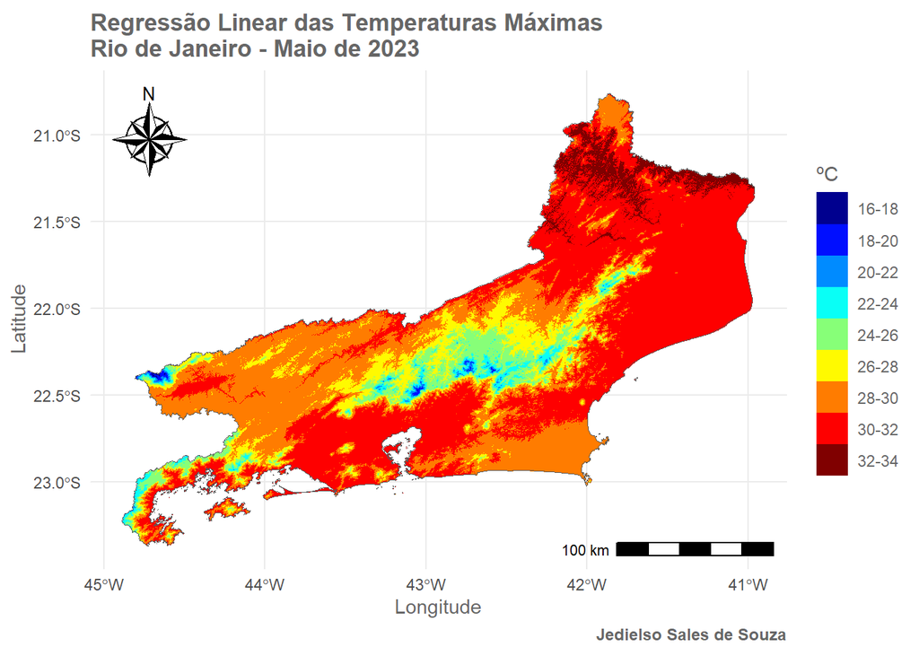

```r
mapa_regressao <- ggplot(data = relevo_rj_df) +
  geom_raster(aes(x = long, y = lat, fill = temp_max_maio_cat)) +
  geom_sf(data = limite, fill = "NA") +
  scale_fill_manual(values = tim.colors(9)) +
  annotation_scale(location = "br") +
  annotation_north_arrow(location = "tl",
                         style = north_arrow_nautical(),
                         height = unit(1.8, "cm"),
                         width = unit(1.8, "cm")) +
  labs(title = "Regressão Linear das Temperaturas Máximas\nRio de Janeiro - Maio de 2023",
       x = "Longitude", y = "Latitude", fill = "ºC", caption = "Jedielso Sales de Souza")+
  theme_minimal() +
  theme(text = element_text(color = "grey40"),
        plot.title = element_text(size = 13, face = "bold"),
        plot.caption = element_text(size = 9, color = "gray40", face = "bold"))

mapa_regressao
```

# Salvando os plots

```r
# Salvando os plots
ggsave(plot = mapa_estacoes, filename = "Plot/mapa_estacoes.jpg",
       height = 4.5, width = 7, units = "in")

ggsave(plot = boxplot_temp_max, filename = "Plot/boxplot_temp_max.jpg",
       height = 6, width = 10, units = "in")

ggsave(plot = mapa_regressao, filename = "Plot/mapa_regressao.jpg",
       height = 4.5, width = 7, units = "in")
```